# Data Visualization and Communication Lab5:ggplot2

Sunwoo Ha

March 2nd, 2018

1. What variables might be related to Commuting times? Load the CommuteStLouis and CommuteAtlanta dataframes from Lock5data into R and combine them into one dataset using rbind(1stDataset, 2ndDataset). Combine and create a basic plot visualizing the relationship between Commute time and and another, reasonable, variable.

   First, lets look at the relationship between all the variables. Here we can see that commute `Time` has a clear positive trend with the `Distance` traveled.

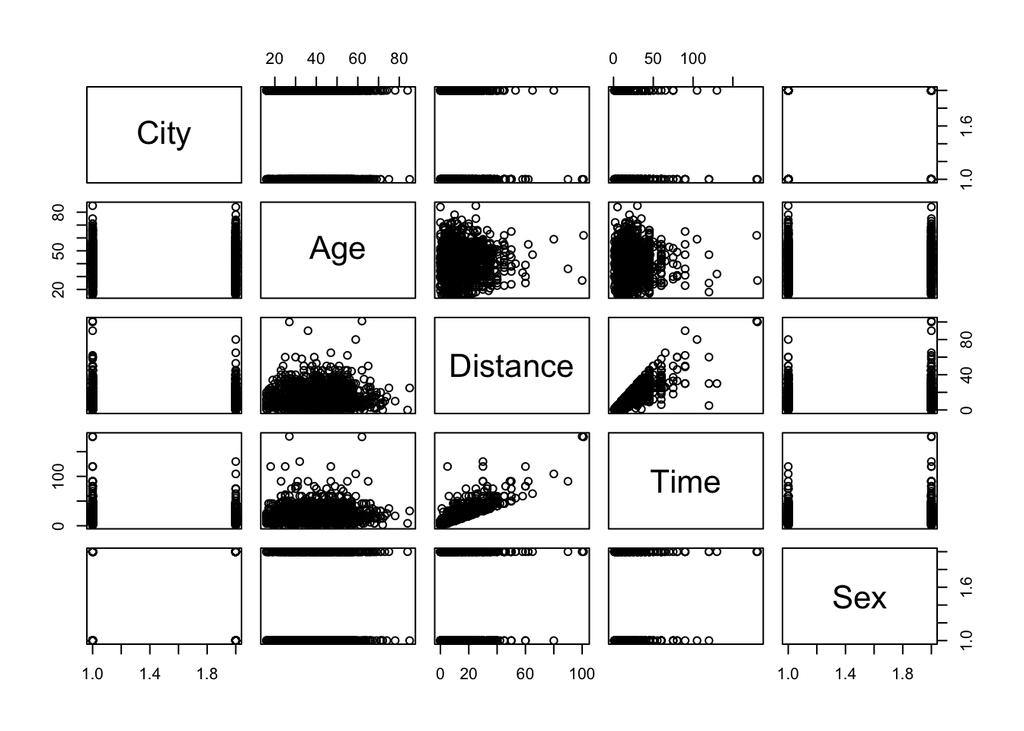

```
Lets get a closer look at the relationship.
```

```r
pairs(commute)
```

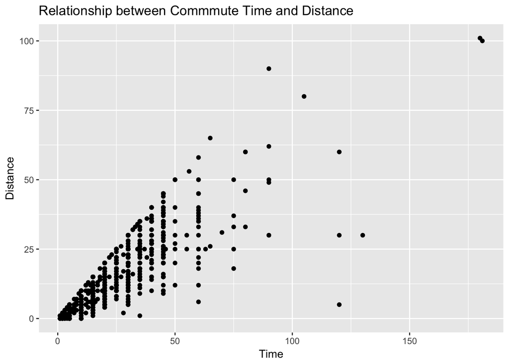

```r
ggplot(commute, aes(x=Time,  y=Distance)) + geom_point() + ggtitle("Relationship between Commmute Time and Distance")
```

2. Do these variables appear to be correlated? Demonstrate this visually. How well does your explanatory variable appear to predict Commute times?

   As explained above, we can see a positive trend with commute `Time` and `Distance`. We should create the linear model to see the relationship more clearly.

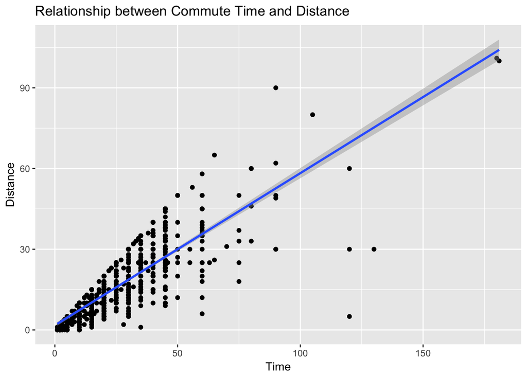

```r
ggplot(commute, aes(x=Time,  y=Distance)) + geom_point() + ggtitle("Relationship between Commute Time and Distance") + geom_smooth(method = "lm")
```

```r
lm.commute <- lm(Distance ~ Time, data = commute)
summary(lm.commute)
```

```
##
## Call:
## lm(formula = Distance ~ Time, data = commute)
##
## Residuals:
##     Min      1Q  Median      3Q     Max
## -64.599  -3.679  -0.850   3.544  37.374
##
## Coefficients:
##             Estimate Std. Error t value Pr(>|t|)
## (Intercept)  1.70602    0.39332   4.338 1.59e-05 ***
## Time         0.56578    0.01256  45.039  < 2e-16 ***
## ---
## Signif. codes:  0 '***' 0.001 '**' 0.01 '*' 0.05 '.' 0.1 ' ' 1
##
## Residual standard error: 7.195 on 998 degrees of freedom
## Multiple R-squared:  0.6702, Adjusted R-squared:  0.6699
## F-statistic:  2028 on 1 and 998 DF,  p-value: < 2.2e-16
```

```
When we look at the summary of the linear model, we can see that the trend is very strong. With a p-value so low along with a correlation of 0.8186852, we can reject the null hypothesis and conclude that there is a significant relationship between `Time` and `Distance`.
```

3. That’s all well and good, but you haven’t slept in three days (#thesisthings) and have begun to forget what all this means. Label your axes and give your graph a brilliant and inspiring title (and maybe an appropriate caption if you’d like). Don’t forget to cite your source somewhere…plagiarism isn’t cool, and someone deserves credit for collecting all this data.

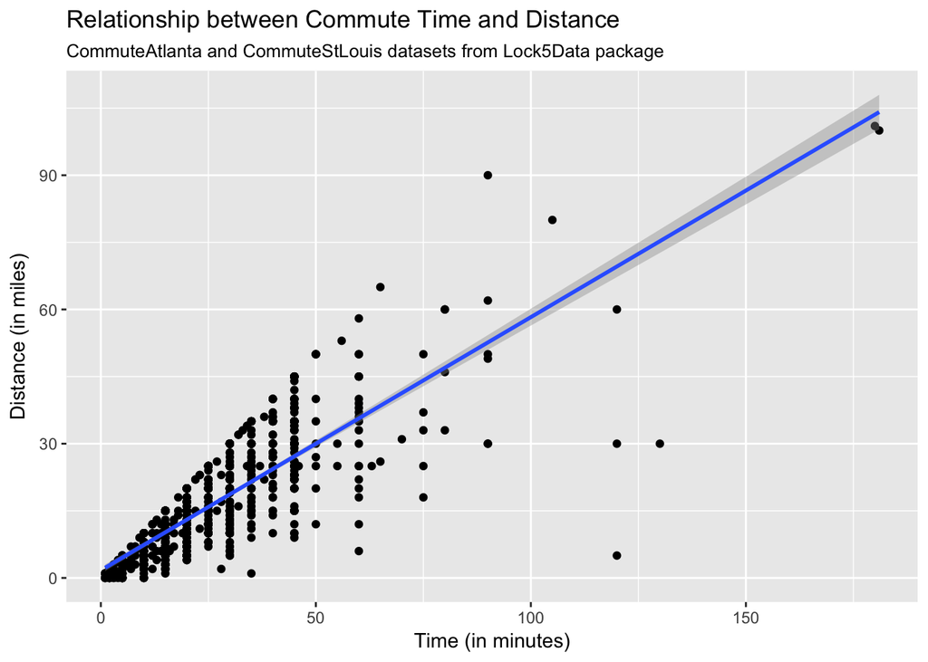

```r
ggplot(commute, aes(x=Time,  y=Distance)) + geom_point() + geom_smooth(method = "lm") + labs(title="Relationship between Commute Time and Distance", subtitle="CommuteAtlanta and CommuteStLouis datasets from Lock5Data package", y="Distance (in miles)", x="Time (in minutes)")
```

4. This plot is good…but is it graphically excellent? Experiment with additional ggplot options to ensure your visualization meets the first 3 Principles of Graphical Excellence. You can reference the following cheat sheet for inspiration: https://www.rstudio.com/wp-content/uploads/2015/03/ggplot2-cheatsheet.pdf.
5. There is still one more principle (excluding truthful) to follow before our visualization can be truly graphically excellent: right now, it’s still only bivariate! Add a layer(s) of data to your visualization. (Hint: How can we group this data effectively?)

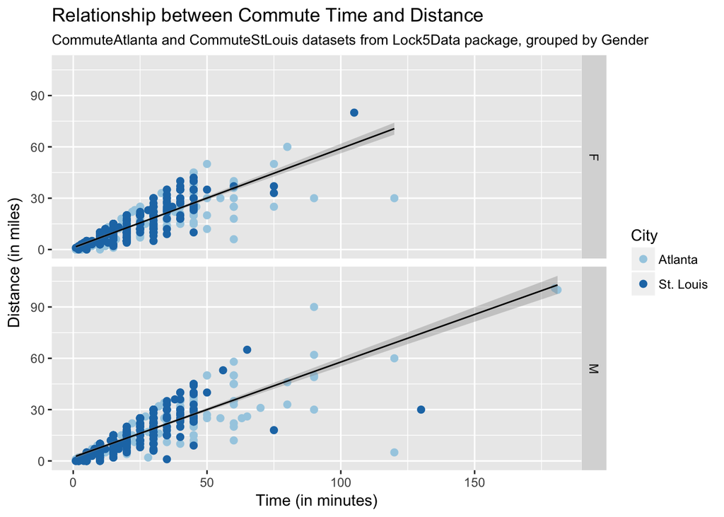

```r
ggplot(commute, aes(x=Time,  y=Distance)) + geom_point(aes(col=City), size = 2) + geom_smooth(method = "lm", col = "black", size = 0.5) + labs(title="Relationship between Commute Time and Distance", subtitle="CommuteAtlanta and CommuteStLouis datasets from Lock5Data package, grouped by Gender", y="Distance (in miles)", x="Time (in minutes)") + facet_grid(Sex ~ .) + scale_colour_brewer(palette = "Paired")
```